# MAT02014 - Planejamento de Experimentos II Introdução aos delineamentos fatoriais

Rodrigo Citton P. dos Reis `rodrigocpdosreis@gmail.com` Universidade Federal do Rio Grande do Sul Instituto de Matemática e Estatística Departamento de Estatística

Porto Alegre, 2018

# Príncipios e definições básicas

## Fatores e delineamentos fatoriais

- Muitos experimentos envolvem o estudo de efeitos de dois ou mais **fatores**.
- Em geral, **delineamentos fatoriais** são mais eficientes para este tipo de experimento.
- Por delineamento fatorial, queremos dizer que em cada replicação completa do experimento todas as possíveis combinações são investigadas.
  - Por exemplo, se existem $a$ níveis do fator $A$ e $b$ níveis do fator $B$, cada replicação contém todas as combinações de tratamentos $ab$.
- Quando os fatores são organizados em um delineamento fatorial, eles costumam ser **cruzados**.

## Fatores e delineamentos fatoriais (comentários)

- De maneira geral, quando se fala de fatoriais não se está falando em delineamentos de experimentos, e sim em **delineamentos de tratamentos**.
  - No entanto, como será visto no curso, existem algumas modificações nos delineamentos básicos que só podem ser aplicadas aos ensaios fatoriais.

## Fatores e delineamentos fatoriais (comentários)

- Chama-se de fator àquilo que se quer testar e de níveis às suas diferentes manifestações.
  - Por exemplo, em estudos de adubação de plantas, três elementos - nitrogênio (N), fósforo (P) e potássio (K) - são considerados os macronutrientes.
    - Assim, cada elemento é considerado um fator, e suas diferentes doses de aplicação níveis.
    - Se apenas um elemento for testado num ensaio, cada nível será chamado de tratamento.
    - Por sua vez, se dois ou três elementos forem testados, cada combinação entre seus níveis é que será declarada como um tratamento.
- Os fatores podem ser **quantitativos**: doses, espaçamento entre plantas, etc; ou **qualitativos**: cultivares, etc.

## Efeitos principais

- O efeito de um fator é definido como a mudança na resposta produzida pela mudança no nível do fator.
  - Este é frequentemente chamado de **efeito principal** porque se refere aos principais fatores no experimento.

### Experimento fatorial com dois fatores com dois níveis

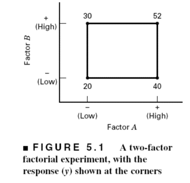

## Efeitos principais

$$A = \bar{y}_{A^{+}} - \bar{y}_{A^{-}} = \frac{40 + 52}{2} - \frac{20 + 30}{2} = 21$$

- **Aumento na média da resposta** de 21 unidades.
- Similarmente, temos que o efeito principal de $B$ é

$$B = \bar{y}_{B^{+}} - \bar{y}_{B^{-}} = \frac{30 + 52}{2} - \frac{20 + 40}{2} = 11$$

## Efeito de interação

- Em alguns experimentos, nós poderemos encontrar que a diferença na resposta entre os níveis de um fator não é o mesmo em todos os níveis dos outros fatores.
- Quando isto ocorre, existe uma **interação** entre os fatores.

### Outro experimento fatorial com dois fatores com dois níveis

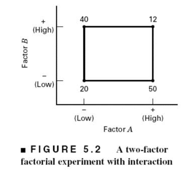

## Efeito de interação

- No nível $B^{-}$, o efeito de $A$ é

$$A = 50 - 20 = 30$$

- No nível $B^{+}$, o efeito de $A$ é

$$A = 12 - 40 = - 28$$

- A magnitude do efeito de interação é a diferença média desses dois efeitos $A$, ou

$$AB = \frac{-28 - 30}{2} = -29$$

## Efeito de interação

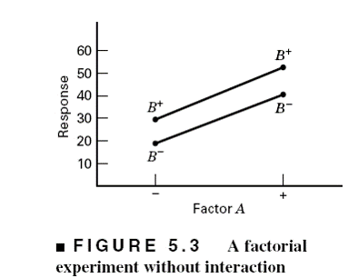

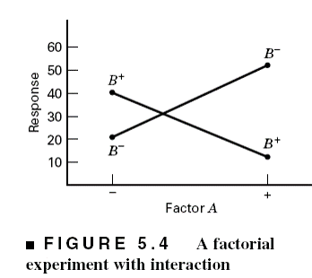

## Representação por modelo de regressão

$$y = \beta_0 + \beta_1x_1 + \beta_2x_2 + \beta_{12}x_1x_2 + \epsilon$$

- $y$ é a resposta
- $\beta$’s são parâmetros
- $x_1$ representa o fator $A$ (escala contínua de -1 a 1)
- $x_2$ representa o fator $B$ (escala contínua de -1 a 1)
- $\epsilon$ é o erro aleatório

## Representação por modelo de regressão (ausência de interação)

$$\hat{y} = 35.5 + 10.5x_1 + 5.5x_2 + 0.5x_1x_2 \approx 35.5 + 10.5x_1 + 5.5x_2$$

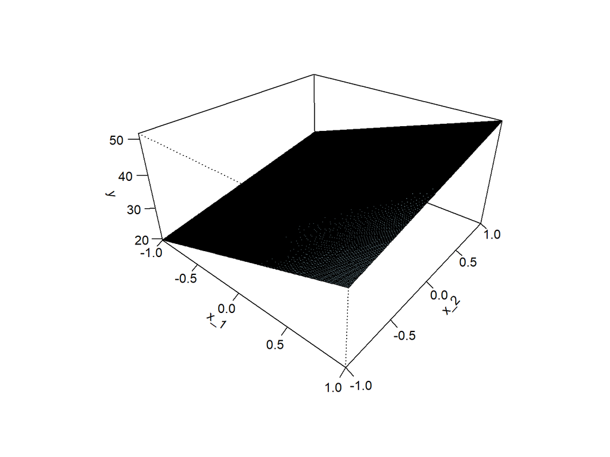

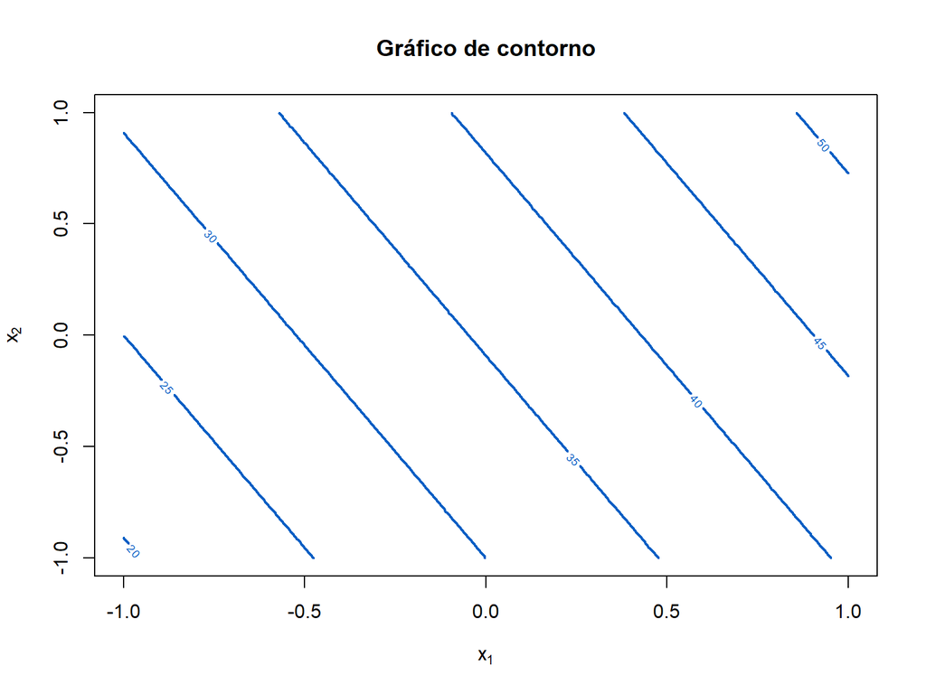

## Representação por modelo de regressão (presença de interação)

$$\hat{y} = 35.5 + 10.5x_1 + 5.5x_2 + 8x_1x_2$$

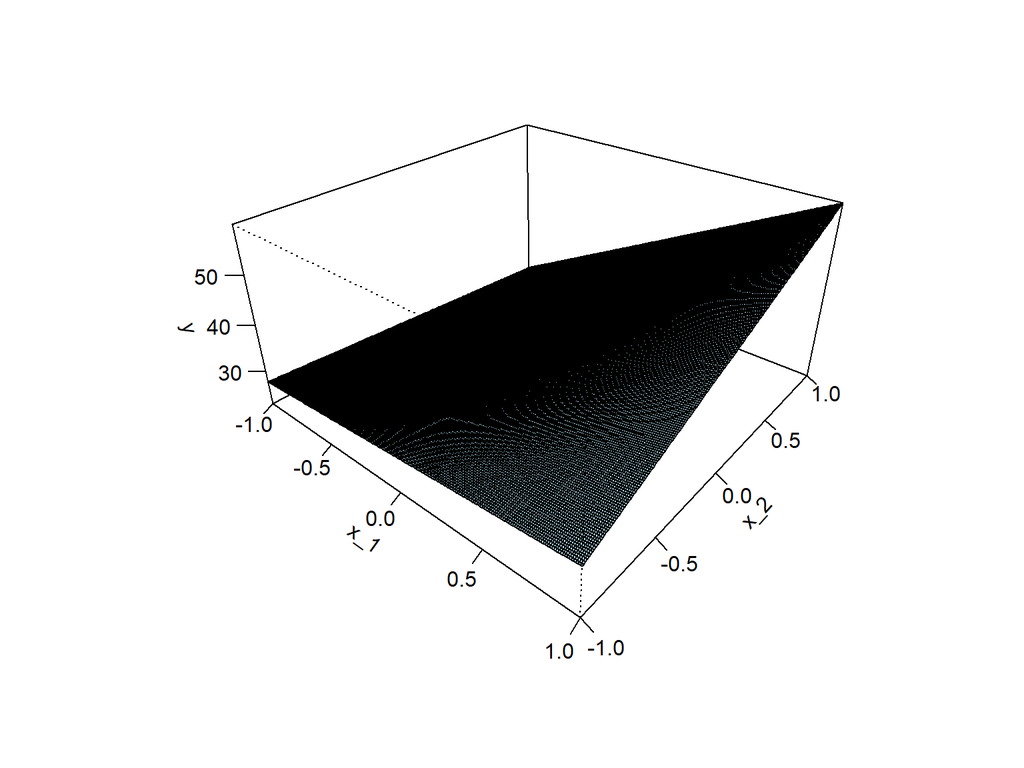

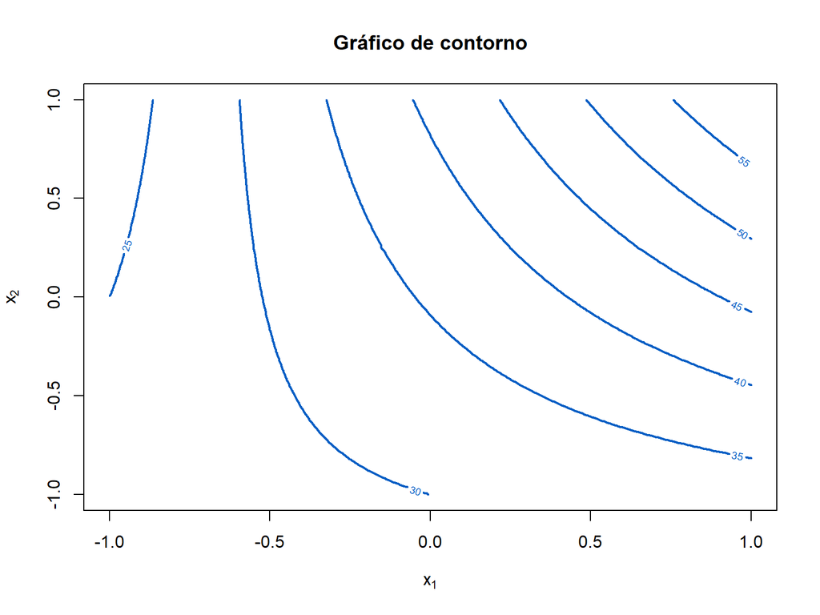

**“Interação é uma forma de curvatura”**

## Efeitos principais *vs* efeito de interação

- Geralmente quando um efeito de interação é grande, os efeitos principais correspondentes têm pouco significado prático.

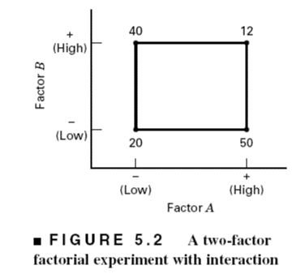

- $A = \bar{y}_{A^{+}} - \bar{y}_{A^{-}} = \frac{50 + 12}{2} - \frac{20 + 40}{2} = 1$, que é bem pequeno, e nós ficamos tentados a concluir que não existe efeito devido ao $A$.
- No entanto, quando examinamos os efeitos de $A$ em *diferentes níveis do fator $B$*, vemos que isto não se confirma.
  - O fator $A$ tem um efeito, mas *depende do nível do fator $B$*.

## Efeitos principais *vs* efeito de interação

- Ou seja, o conhecimento da interação $AB$ é mais útil que o conhecimento do efeito principal.
- Uma interação significativa geralmente irá **mascarar** a significância dos efeitos principais.
- Na presença de interação significativa, o pesquisador deve usualmente examinar os níveis de um fator, fator $A$, com os níveis do outro fator fixados para obter conclusões sobre efeito principal de $A$.

# Delineamento fatorial com dois fatores

## Delineamento fatorial com dois fatores

- Os tipos de delineamentos fatoriais mais simples envolvem apenas dois fatores ou conjuntos de tratamentos.
- Existem $a$ níveis do fator $A$ e $b$ níveis do fator $B$, e estes são organizados em um delineamento fatorial.

## Exemplo da bateria

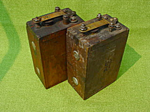

- Um engenheiro está desenhando uma bateria para ser usada em um dispositivo que estará sujeita a variações de temperatura.
  - Três tipos de materiais (MT) são possíveis para a fabricação da bateria.
  - Três temperaturas, consistentes com as temperaturas do ambiente de uso.
  - Quatro baterias foram testadas em cada combinação de material e temperatura.
- **Delineamento fatorial $3^2$**.

## Exemplo da bateria

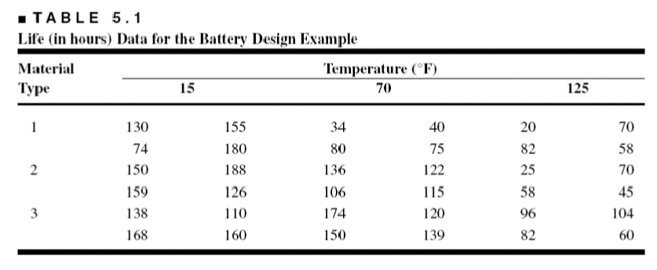

1. Quais os efeitos do tipo e temperatura do material na vida?
2. Existe uma escolha de material que daria vida longa, independentemente da temperatura (um **produto robusto**)?

## Exemplo da bateria

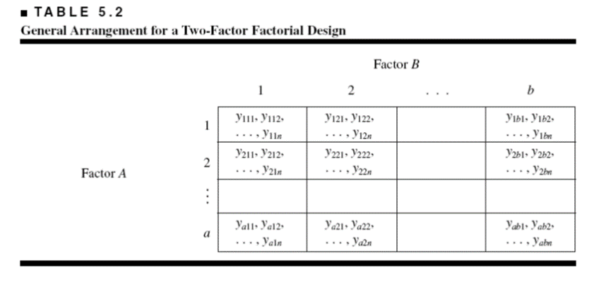

- $a$ níveis do fator $A$; $b$ níveis do fator $B$; $n$ replicações.
- Este é um **delineamento completamente aleatorizado**.

## Exemplo da bateria

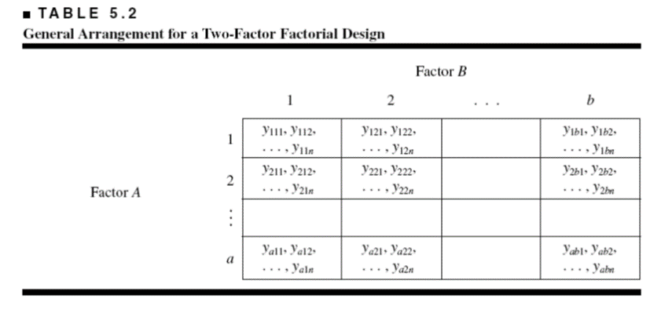

- O **modelo de efeitos**:

$$y_{ijk} = \mu + \tau_i + \beta_j + (\tau\beta)_{ij} + \epsilon_{ijk}, i = 1, \ldots, a, j = 1,\ldots, b, k = 1, \ldots, n.$$

## Exemplo da bateria

- Em um experimento fatorial com dois fatores, os fatores $A$ e $B$ são de igual interesse.
- Especificamente, estamos interessados em **testar hipóteses** sobre a igualdade dos efeitos de tratamento das linhas

$$H_0: \tau_1 = \tau_2 = \ldots = \tau_a = 0\quad vs.\quad H_1:\mbox{pelo menos um } \tau_i \neq 0$$
e a igualdade dos efeitos de tratamento das colunas

$$H_0: \beta_1 = \beta_2 = \ldots = \beta_b = 0\quad vs.\quad H_1:\mbox{pelo menos um } \beta_j \neq 0$$

- Também estamos interessados em determinar em que linha e coluna os tratamentos *interagem*

$$H_0: (\tau\beta)_{ij} = 0\quad vs.\quad H_1:\mbox{pelo menos um } (\tau\beta)_{ij} \neq 0$$
- **Pergunta:** O que estas hipóteses representam na prática? - *Cenas dos próximos capítulos:* **Análise de variância de dois fatores**

# Criando um planejamento fatorial com dois fatores no `R`

## Exemplo da bateria

```r
D <- expand.grid(MT = 1:3, T = c(15, 70, 125))
D
```

```
##   MT   T
## 1  1  15
## 2  2  15
## 3  3  15
## 4  1  70
## 5  2  70
## 6  3  70
## 7  1 125
## 8  2 125
## 9  3 125
```

```r
D <- rbind(D, D, D, D)
set.seed(2591)
D <- D[order(sample(1:36)), ]
BatteryDes <- D[ c( "MT", "T" )]
BatteryDes
write.csv(BatteryDes, file = "BatteryDes.csv", row.names = FALSE)
```

[output not shown]

# As vantagens dos delineamentos fatoriais

## Para casa

- Discuta as vantagens dos delineamentos fatoriais em comparação com o delineamento *um fator por vez*.
  - Veja Czitrom, V. “One-Factor-at-a-Time Versus Designed Experiments”. *The American Statistician*, 53:126-131, 1999.